# Whose Destiny Did Demographics Decide?: Visualizing the 2020 Cooperative Election Study (CCES)

Bradley Wascher

Originally 5/17/2021

Joe Biden’s victory over Donald Trump in the 2020 election came thanks to a broad coalition…sort of. But what exactly did that coalition look like? And how did it compare to that of Hillary Clinton in 2016, or previous Democratic presidential candidates? These answers and more can be found in the [Cooperative Election Study](https://cces.gov.harvard.edu/).

The Cooperative Election Study, also known as the Cooperative Congressional Election Study or CCES, is a comprehensive survey of over 50,000 respondents across the United States, administered online via YouGov as part of a joint effort between dozens of different academic and research institutions. Although the CCES is conducted annually, its election-year installments are special in that they’re fielded in two waves: one before the election, and one after. Due to its large sample size and vote validation after the fact, the CCES is [considered to be](https://fivethirtyeight.com/videos/be-wary-of-exit-polls-this-year-well-and-all-years/) a more rigorous alternative to the exit polls taken on Election Day. At the very least, [it is widely agreed](https://centerforpolitics.org/crystalball/articles/another-look-back-at-2016/) that the CCES is a reliable reference for anyone curious about who voted for whom on the Tuesday next after the first Monday last November.

The following visualizations will seek to give additional context to the recently released [2020 Cooperative Election Study post-election wave](https://dataverse.harvard.edu/dataset.xhtml?persistentId=doi%3A10.7910/DVN/E9N6PH) by analyzing support for Biden and Trump across various demographic groups, and then comparing those to the equivalent estimates from the 2016 Cooperative Congressional Election Study. All data has been reweighted using the information provided by the CCES.

## Visualizations 1 & 2: CCES Estimates vs. 2020 Results

Before diving in, it’s important to remember that the Cooperative Election Study is still just a poll. As a result, its estimates don’t always line up with the real outcome of the election. The first map compares the state-level estimates from the 2020 CCES to the true results, whereas the second map compares the proportion of a state’s respondents to its contribution to the national popular vote:

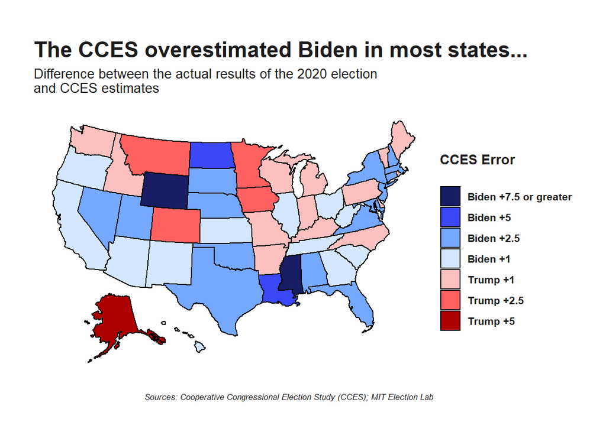

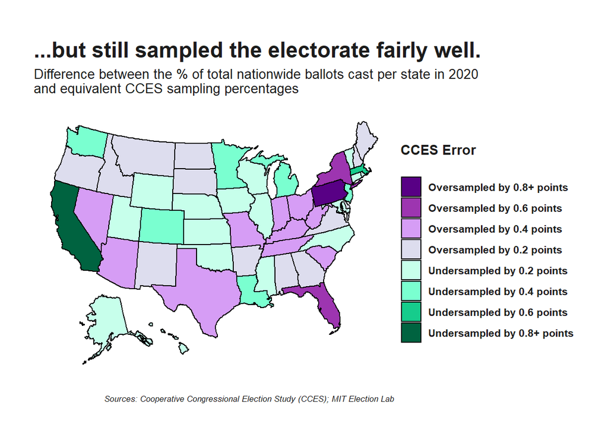

## Visualizations 3 & 4: Election Results by Gender

Although politics in the United States have become increasingly polarized [over the last two decades especially](https://www.pewresearch.org/politics/2019/12/17/in-a-politically-polarized-era-sharp-divides-in-both-partisan-coalitions/), one demographic gap has been drawn out along party lines for the better part of the [past 40 years](https://www.pewresearch.org/politics/2019/12/17/in-a-politically-polarized-era-sharp-divides-in-both-partisan-coalitions/). Indeed, women continued to vote for Democrats at higher rates than they did for Republicans in 2020, even more so than in 2016 — while support among men improved for both Trump and Biden. Per the 2016 CCES, Hillary Clinton earned 53 percent of women voters, compared to 42 percent for Donald Trump. Joe Biden further built on this advantage four years later, earning a slightly larger share (56-43) over Trump relative to Clinton. In both 2016 and 2020, Trump earned more support among men.

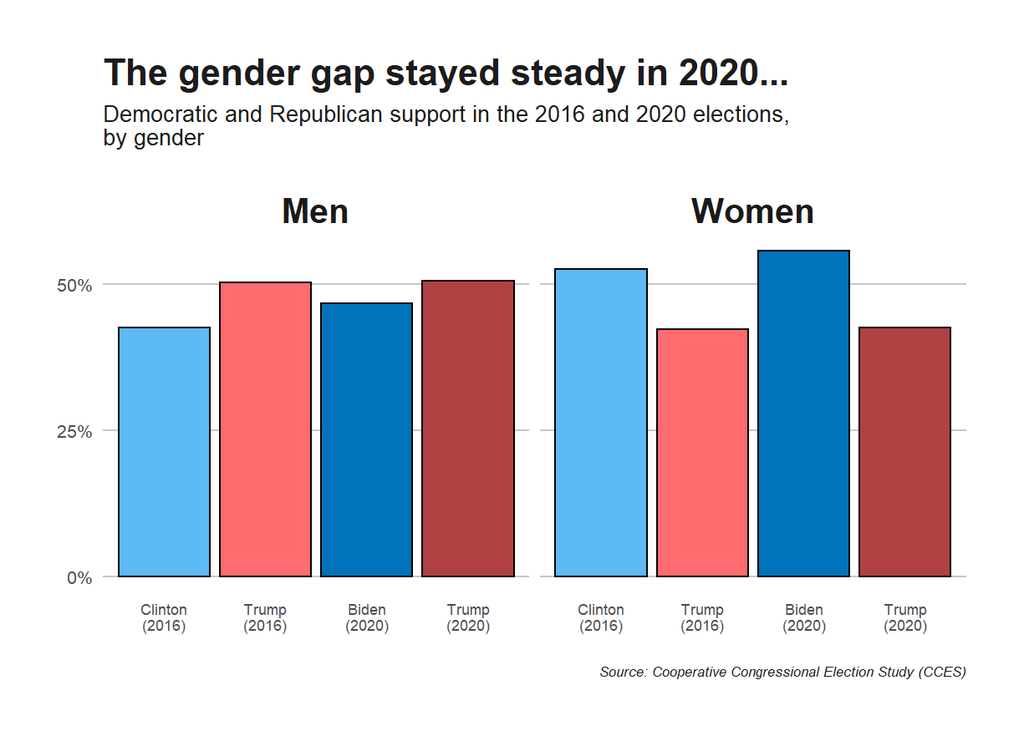

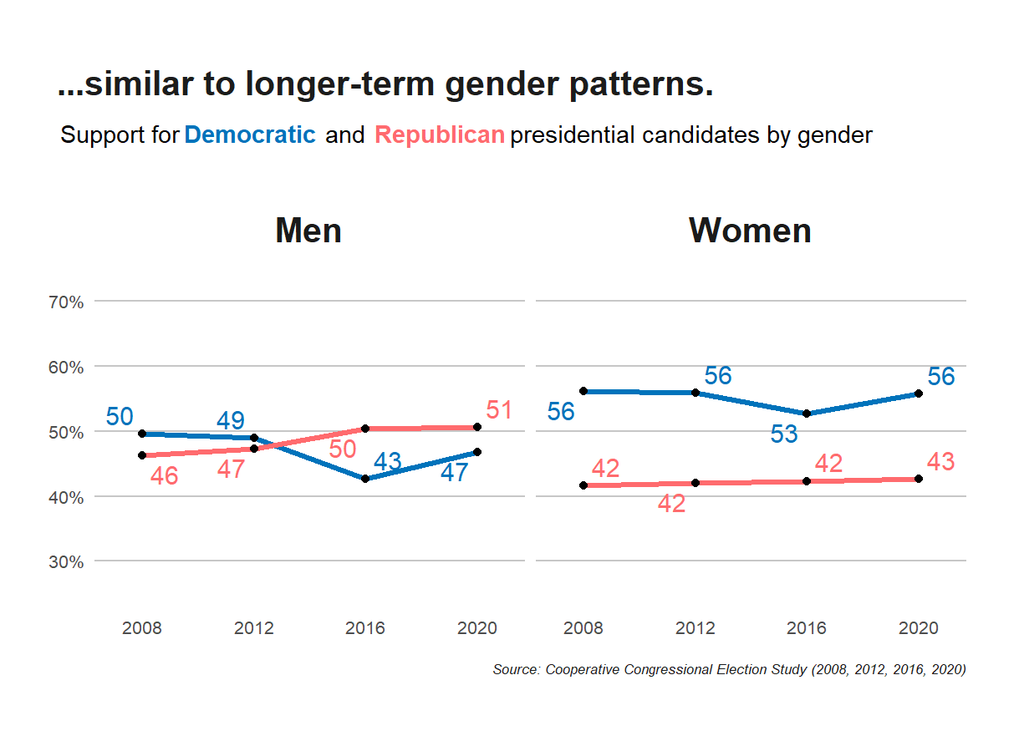

## Visualizations 5 & 6: Election Results by Education

One of the [big stories](https://www.brookings.edu/research/americas-electoral-future_2018/) of the 2016 election was Donald Trump’s strong support among voters without a college degree: the 2016 CCES approximates that he won this group 51-44 — and he did even better among white voters without a college degree in particular. Likewise, Hillary Clinton was substantially more popular than Trump (55-38) among those who said they had at least a bachelor’s degree.

According to the 2020 CCES, these gaps grew even larger. While Trump’s support among voters without a college degree hovered at a similar position in both 2016 and 2020, Joe Biden’s advantage among voters with a college degree grew to around 20 points, a marked improvement from Clinton’s already impressive showing four years earlier. These differences raise questions about the long-term trajectory of this educational divide: in the span of just a few cycles, the gap has gone from a [relative non-factor in elections](https://www.pewresearch.org/fact-tank/2016/09/15/educational-divide-in-vote-preferences-on-track-to-be-wider-than-in-recent-elections/) to one of the [most important demographic trends of all](https://www.nytimes.com/2020/05/12/upshot/polls-2020-trump-biden.html).

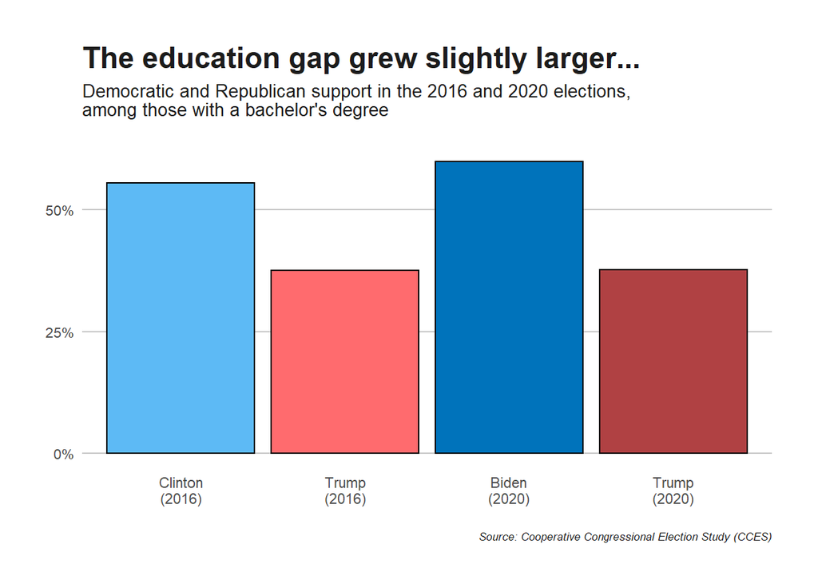

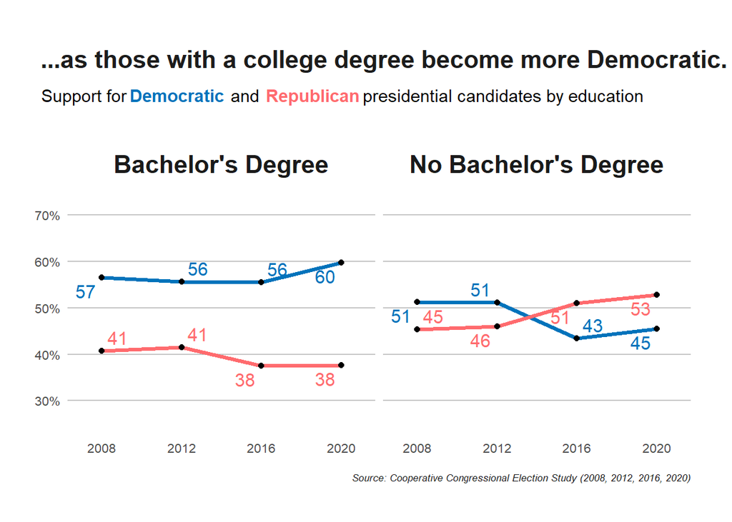

## Visualizations 7 & 8: Election Results by Race

Many of the differences between the 2016 and 2020 CCES are too close to tell for certain, but there’s other evidence in favor of the theory that Trump gained support among certain minority voters. Areas including [Miami-Dade County in Florida](https://twitter.com/xxxneonslavexxx/status/1328853223214559233) and [the Rio Grande Valley in Texas](https://www.theguardian.com/commentisfree/2020/nov/24/the-10-swing-state-counties-that-tell-the-story-of-the-2020-election), both of which are areas with high Hispanic populations, veered toward Trump by as much as 20 or 30 points last November; the latest CCES estimates, on the other hand, showed Trump gaining just a few points among Hispanic voters overall between 2016 and 2020. To be sure, the possibility that Hispanic voters were underrepresented in 2020 pre-election polls is [one that pollsters recognize](https://www.nytimes.com/2020/11/10/upshot/polls-what-went-wrong.html) — it also doesn’t help that the CCES lists only ‘Hispanic’ as an answer on its questionnaire, rather than providing more specific choices (such as nationality) that might more faithfully capture the contours of this demographic group.

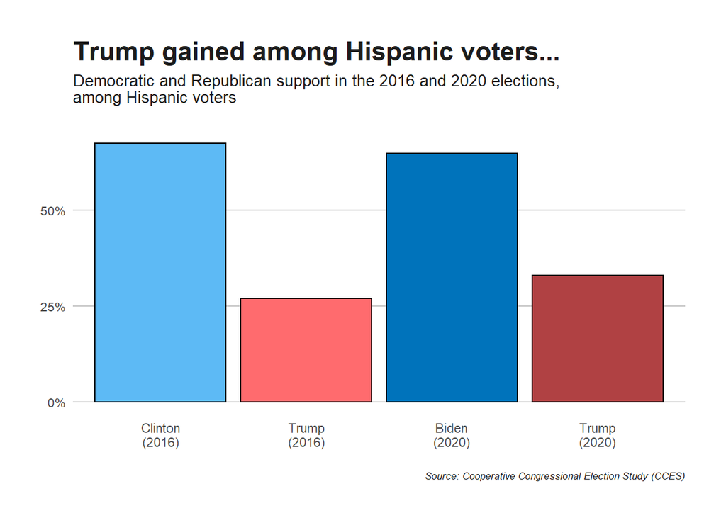

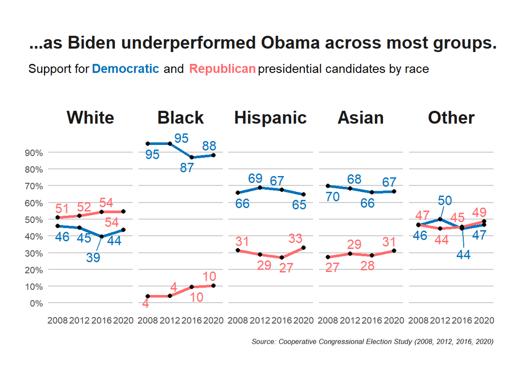

## Visualizations 9 & 10: Election Results by Age

In the lead-up to the 2020 election, there was much [chatter](https://www.brookings.edu/blog/the-avenue/2020/10/28/older-voters-may-secure-a-biden-victory-in-2020s-swing-states/) online about Joe Biden’s strong support among older voters. Although the 2016 CCES suggested that Donald Trump carried voters over the age of 65 by 13 points nationwide against Hillary Clinton, [some state-level polling](https://int.nyt.com/data/documenttools/flpa-0930-crosstabs/16c21b7ab34ed4d1/full.pdf) conducted weeks before the 2020 race showed Joe Biden ahead among this group. But in the end, that support didn’t fully materialize, as the 2020 CCES post-election survey suggested Trump won among voters over 65 by 9 points against Biden, continuing a streak of sorts for Republican presidential candidates.

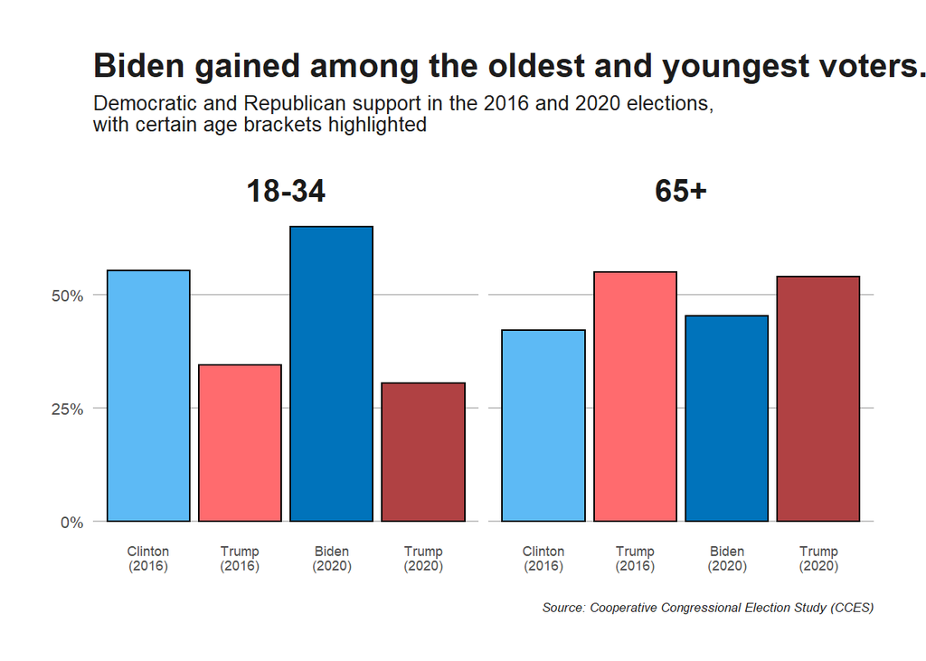

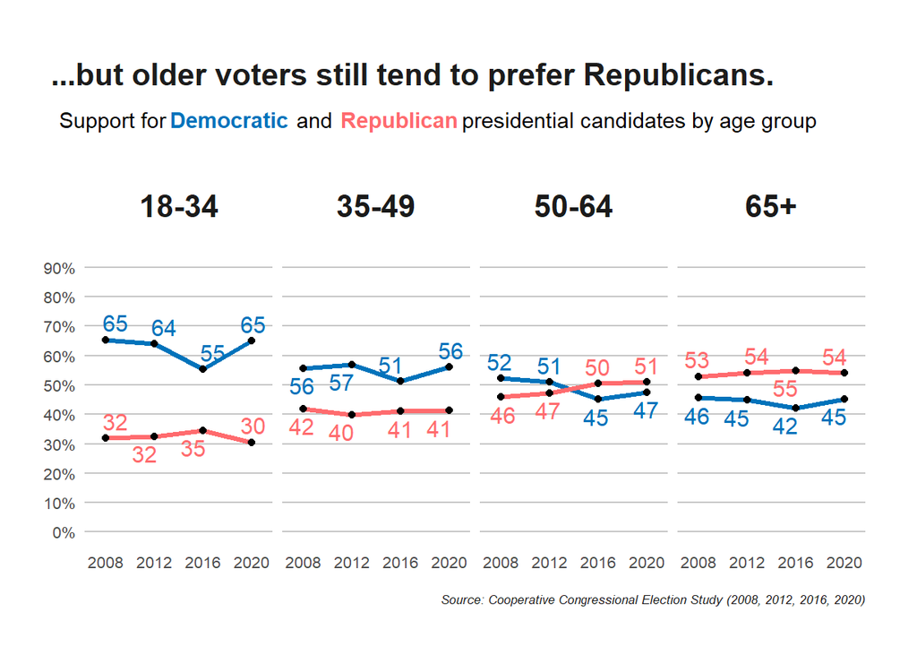

## Closing Thoughts

The 2020 election certainly had its surprises. But six months later, more information has allowed some of those questions to be answered.

Using data from the 2016 and 2020 post-election waves of the Cooperative Election Study, the preceding visualizations have compared support for Hillary Clinton, Joe Biden, and Donald Trump by gender, educational attainment, race, and age. This preliminary analysis suggests that Biden improved upon Clinton’s margins in groups such as younger voters and voters with a college degree. While certain other estimates from the CCES do not appear to be substantively different between both elections years, these findings are not conclusive, and future research could serve to establish clarity on these issues.